# Exercícios — Regressão Logística (R)

08 dezembro 2025

## Exercício 1 — Titanic

### 1. Por que não avaliar no mesmo conjunto usado para ajustar?

Se ajustarmos o modelo **e** avaliarmos o desempenho (accuracy, sensibilidade, especificidade, AUC) nos **mesmos dados**:

- o modelo foi “treinado” para se adaptar àquele conjunto,
- tende a **sobreajustar** (overfitting),
- as métricas serão **otimistas**: medem quão bem o modelo se ajusta aos dados vistos, não quão bem generaliza para novos passageiros.

Ao usar:

- dados de treino para **ajustar**
- dados de teste para **avaliar**

obtemos uma estimativa mais realista do desempenho em dados futuros.

### 2. Ajustar o modelo logístico e interpretar coeficientes

```r
library(titanic)
library(dplyr)

dados_titanic <- titanic_train %>%
select(Survived, Pclass, Sex, Age, Fare) %>%
na.omit()

dados_titanic$Sex <- factor(dados_titanic$Sex,
levels = c("male", "female"))

set.seed(123)
n <- nrow(dados_titanic)
idx_treino <- sample(seq_len(n), size = 0.8 * n)

dados_titanic_treino <- dados_titanic[idx_treino, ]
dados_titanic_teste  <- dados_titanic[-idx_treino, ]

modelo_titanic <- glm(
Survived ~ Pclass + Sex + Age + Fare,
data   = dados_titanic_treino,
family = binomial
)

summary(modelo_titanic)
```

```
##
## Call:
## glm(formula = Survived ~ Pclass + Sex + Age + Fare, family = binomial,
##     data = dados_titanic_treino)
##
## Coefficients:
##               Estimate Std. Error z value Pr(>|z|)
## (Intercept)  2.1325309  0.5613653   3.799 0.000145 ***
## Pclass      -1.1841742  0.1702903  -6.954 3.55e-12 ***
## Sexfemale    2.4353880  0.2269507  10.731  < 2e-16 ***
## Age         -0.0326120  0.0083008  -3.929 8.54e-05 ***
## Fare         0.0006545  0.0022337   0.293 0.769519
## ---
## Signif. codes:  0 '***' 0.001 '**' 0.01 '*' 0.05 '.' 0.1 ' ' 1
##
## (Dispersion parameter for binomial family taken to be 1)
##
##     Null deviance: 766.59  on 570  degrees of freedom
## Residual deviance: 530.06  on 566  degrees of freedom
## AIC: 540.06
##
## Number of Fisher Scoring iterations: 4
```

- `Pclass` é codificada como 1, 2, 3 (1ª, 2ª, 3ª classe).
- Tipicamente o estimador vem **negativo**: $\hat\beta_1 < 0$.

Interpretação:

- À medida que a classe **aumenta** (passa de 1 para 2, ou de 2 para 3), ou seja, o passageiro vai para uma classe **mais baixa**, a **log-odds** de sobreviver **diminuem**.
- Logo, passageiros em classes mais altas (1ª) tendem a ter **maior probabilidade de sobrevivência** que os de 2ª, que por sua vez têm maior probabilidade que os de 3ª (mantendo sexo, idade e fare fixos).

#### Interpretação de $\beta_2$ (Sex)

Com `Sex` codificada como fator com níveis `male` (referência) e `female`:

- O coeficiente reportado é para `Sexfemale`.
- Tipicamente, $\hat\beta_2 > 0$ e altamente significativo.

Interpretação:

- $\hat\beta_2 > 0$: a **log-odds** de sobreviver é maior para mulheres do que para homens, tudo o resto constante.
- $e^{\hat\beta_2}$ é a **odds ratio**: quantas vezes as *odds* de sobrevivência de uma mulher são maiores do que as de um homem com mesma Pclass, Age e Fare.

### 3. Previsões no conjunto de teste, matriz de confusão e métricas

Obter probabilidades previstas:

```r
prob_teste <- predict(
  modelo_titanic,
  newdata = dados_titanic_teste,
  type = "response"
)

head(prob_teste)
```

```
##         1         3        10        21        25        35
## 0.1059578 0.5430605 0.8535454 0.2042041 0.6831516 0.5222351
```

Classificar com threshold (t = 0.5):

```r
pred_class <- ifelse(prob_teste >= 0.5, 1, 0)

tab <- table(
  Observado  = dados_titanic_teste$Survived,
  Previsto   = pred_class
)
tab
```

```
##          Previsto
## Observado  0  1
##         0 71  8
##         1 17 47
```

A partir da matriz:

- (TP) = verdadeiros positivos (Survived=1 e Previsto=1)
- (TN) = verdadeiros negativos
- (FP) = falsos positivos
- (FN) = falsos negativos

```r
TP <- tab["1","1"]
TN <- tab["0","0"]
FP <- tab["0","1"]
FN <- tab["1","0"]

accuracy  <- (TP + TN) / sum(tab)
sens      <- TP / (TP + FN)  # TPR
espec     <- TN / (TN + FP)  # TNR

accuracy
```

```
## [1] 0.8251748
```

```r
sens
```

```
## [1] 0.734375
```

```r
espec
```

```
## [1] 0.8987342
```

Interpretação típica:

- **Accuracy** → proporção global de classificações corretas.
- **Sensibilidade** → entre os que sobreviveram, que fração o modelo identificou como “sobrevive”?
- **Especificidade** → entre os que não sobreviveram, que fração o modelo identificou corretamente como “não sobrevive”?

### 4. Curva ROC e AUC com `pROC`

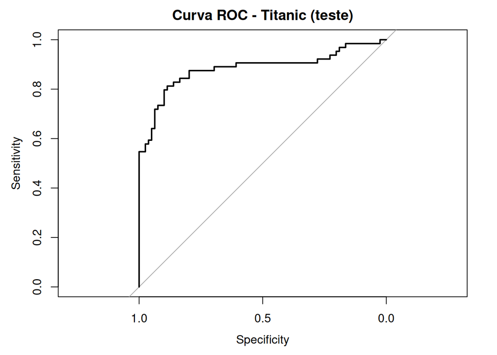

```r
library(pROC)

roc_titanic <- roc(
  response = dados_titanic_teste$Survived,
  predictor = prob_teste
)

plot(roc_titanic, main = "Curva ROC - Titanic (teste)")
```

```r
auc(roc_titanic)
```

```
## Area under the curve: 0.8833
```

- A curva ROC mostra o **trade-off** entre sensibilidade e 1 − especificidade para todos os thresholds.
- A **AUC** é a área sob a curva:
  - AUC ≈ 0.5 → modelo aleatório
  - AUC perto de 1 → excelente capacidade discriminativa
  - Para este tipo de modelo Titanic simples, é comum obter AUC > 0.8 (indica boa separação entre sobreviventes e não sobreviventes).

Interpretação:

> A AUC pode ser interpretada como a probabilidade de o modelo atribuir uma probabilidade mais alta de sobrevivência a um passageiro que de facto sobreviveu do que a um passageiro que não sobreviveu, escolhidos ao acaso.

## Exercício 2 — Default (ISLR2)

### 1. Criar (Y) binário e justificar regressão logística

```r
library(ISLR2)

dados_default <- Default
dados_default$Y <- ifelse(dados_default$default == "Yes", 1, 0)
table(dados_default$Y)
```

```
##
##    0    1
## 9667  333
```

Por que **regressão logística** em vez de linear?

- A resposta (Y) é **binária** (0/1).
- A regressão linear pode prever valores **fora de [0,1]** e não respeita a estrutura de probabilidade.
- A regressão logística modela:

  $$\operatorname{logit}(P(Y=1 \mid X)) = \beta_0 + \cdots$$

  e garante que $0 \le P(Y=1 \mid X) \le 1$.
- A função de verosimilhança é adequada a dados binários (modelo Bernoulli/Binomial).

### 2. Divisão treino/teste e proporções de incumpridores

```r
set.seed(123)

n <- nrow(dados_default)
idx_treino <- sample(seq_len(n), size = 0.6 * n)

treino_default <- dados_default[idx_treino, ]
teste_default  <- dados_default[-idx_treino, ]

prop_treino <- mean(treino_default$Y)
prop_teste  <- mean(teste_default$Y)

prop_treino
```

```
## [1] 0.03316667
```

```r
prop_teste
```

```
## [1] 0.0335
```

- As proporções devem ser relativamente semelhantes (se a amostragem foi aleatória), o que é desejável para ter treino e teste representativos.

### 3. Ajustar o modelo logístico e interpretar coeficientes

```r
modelo_default <- glm(
  Y ~ balance + income + student,
  data   = treino_default,
  family = binomial
)

summary(modelo_default)
```

```
##
## Call:
## glm(formula = Y ~ balance + income + student, family = binomial,
##     data = treino_default)
##
## Coefficients:
##               Estimate Std. Error z value Pr(>|z|)
## (Intercept) -1.101e+01  6.467e-01 -17.025   <2e-16 ***
## balance      5.783e-03  3.001e-04  19.268   <2e-16 ***
## income       4.274e-06  1.081e-05   0.395   0.6925
## studentYes  -5.641e-01  3.081e-01  -1.831   0.0672 .
## ---
## Signif. codes:  0 '***' 0.001 '**' 0.01 '*' 0.05 '.' 0.1 ' ' 1
##
## (Dispersion parameter for binomial family taken to be 1)
##
##     Null deviance: 1747.00  on 5999  degrees of freedom
## Residual deviance:  926.42  on 5996  degrees of freedom
## AIC: 934.42
##
## Number of Fisher Scoring iterations: 8
```

#### $\beta_1$ (balance)

- Tipicamente, $\hat\beta_1 > 0$ e altamente significativo.
- Interpretação:
  - Quanto maior o **saldo médio** no cartão (`balance`), maiores as **log-odds** de incumprimento.
  - $e^{\hat\beta_1}$ é o fator pela qual as *odds* de incumprimento se multiplicam quando o saldo aumenta uma unidade (por exemplo, 1 dólar, dependendo da unidade usada).

#### $\beta_3$ (student)

Com `student` como factor (`No` de referência e `Yes`):

- Se $\hat\beta_3 > 0$:
  - ser estudante aumenta as log-odds de incumprimento, comparado a não ser estudante, a `balance` e `income` fixos.
- Se $\hat\beta_3 < 0$:
  - ser estudante diminui as log-odds de incumprimento.

Em qualquer dos casos:

- $e^{\hat\beta_3}$ é a **odds ratio** entre estudantes e não estudantes:
  - valor > 1 → estudantes têm maior risco,
  - valor < 1 → estudantes têm menor risco, ajustando para `balance` e `income`.

### 4. Previsões no teste, matriz de confusão, sensibilidade e especificidade

Probabilidades previstas no teste:

```r
prob_default_teste <- predict(
  modelo_default,
  newdata = teste_default,
  type = "response"
)

head(prob_default_teste)
```

```
##            2            3            6            7            8           10
## 1.116155e-03 9.322154e-03 1.976950e-03 2.172331e-03 1.087815e-03 1.873213e-05
```

Classificação com (t = 0.5):

```r
pred_default <- ifelse(prob_default_teste >= 0.5, 1, 0)

tab_default <- table(
  Observado = teste_default$Y,
  Previsto  = pred_default
)
tab_default
```

```
##          Previsto
## Observado    0    1
##         0 3853   13
##         1   93   41
```

Métricas:

```r
TP <- tab_default["1","1"]
TN <- tab_default["0","0"]
FP <- tab_default["0","1"]
FN <- tab_default["1","0"]

accuracy  <- (TP + TN) / sum(tab_default)
sens      <- TP / (TP + FN)   # verdadeiro positivo
espec     <- TN / (TN + FP)   # verdadeiro negativo

accuracy
```

```
## [1] 0.9735
```

```r
sens
```

```
## [1] 0.3059701
```

```r
espec
```

```
## [1] 0.9966374
```

Comentário:

- Em problemas de risco de crédito, **falsos negativos** (classificar como seguro alguém que vai incumprir) são muito caros.
- Muitas vezes é preferível **aumentar a sensibilidade** (detetar mais incumpridores), mesmo à custa de aumentar FP e baixar especificidade.

### 5. Curva ROC, AUC e threshold ótimo (Youden)

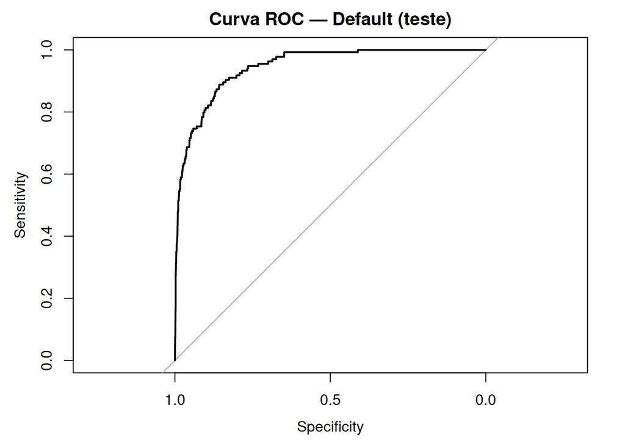

```r
library(pROC)

roc_default <- roc(
  response  = teste_default$Y,
  predictor = prob_default_teste
)

plot(roc_default, main = "Curva ROC — Default (teste)")
```

```r
auc(roc_default)
```

```
## Area under the curve: 0.9451
```

Threshold ótimo pelo índice de Youden:

```r
coords_default <- coords(
  roc_default,
  x = "best",
  best.method = "youden",
  transpose = TRUE
)
coords_default
```

```
##   threshold specificity sensitivity
##  0.03177046  0.85747543  0.88805970
```

- `coords_default["threshold"]` → threshold ótimo
- Também dá sensibilidade e especificidade nesse ponto.

Recalcular matriz de confusão com threshold ótimo:

```r
t_opt <- coords_default["threshold"]

pred_default_opt <- ifelse(prob_default_teste >= t_opt, 1, 0)

tab_opt <- table(
  Observado = teste_default$Y,
  Previsto  = pred_default_opt
)
tab_opt
```

```
##          Previsto
## Observado    0    1
##         0 3315  551
##         1   15  119
```

```r
TP2 <- tab_opt["1","1"]
TN2 <- tab_opt["0","0"]
FP2 <- tab_opt["0","1"]
FN2 <- tab_opt["1","0"]

accuracy2 <- (TP2 + TN2) / sum(tab_opt)
sens2     <- TP2 / (TP2 + FN2)
espec2    <- TN2 / (TN2 + FP2)

accuracy2
```

```
## [1] 0.8585
```

```r
sens2
```

```
## [1] 0.8880597
```

```r
espec2
```

```
## [1] 0.8574754
```

Comparar:

- Se o threshold ótimo estiver **abaixo de 0.5**, em geral:
  - **aumenta a sensibilidade** (deteta mais incumpridores),
  - reduz especificidade (mais falsos positivos).
- Em contexto de crédito, isso pode ser aceitável se o custo de conceder empréstimo a um mau pagador for muito maior que o custo de recusar um bom pagador.